# Assignment 5 - Bike Share Demand Forecasting

### 2.2.3 Mapping Station Usage and frequency

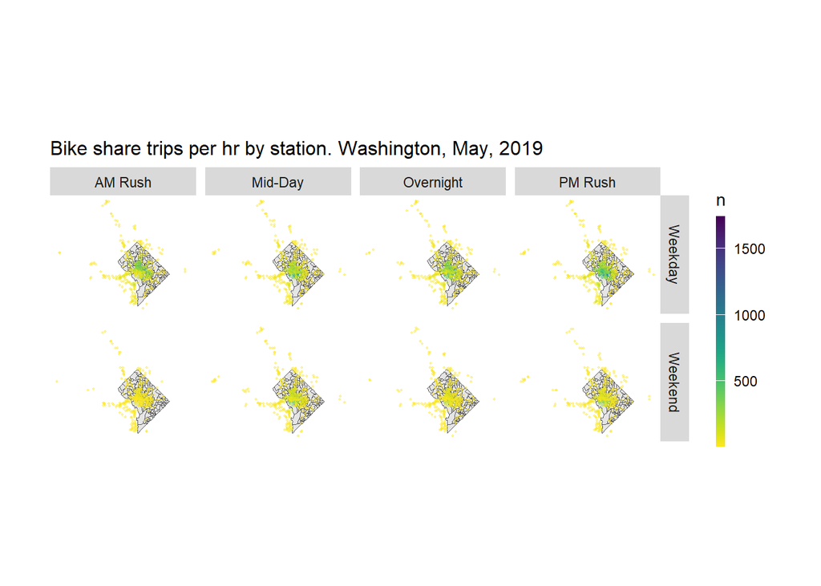

```r
ggplot()+
  geom_sf(data = dcTracts %>%
          st_transform(crs=4326))+
  geom_point(data = dat_census %>%
            mutate(hour = hour(Start.date),
                weekend = ifelse(dotw %in% c("Sun", "Sat"), "Weekend", "Weekday"),
                time_of_day = case_when(hour(interval60) < 7 | hour(interval60) > 18 ~ "Overnight",
                                 hour(interval60) >= 7 & hour(interval60) < 10 ~ "AM Rush",
                                 hour(interval60) >= 10 & hour(interval60) < 15 ~ "Mid-Day",
                                 hour(interval60) >= 15 & hour(interval60) <= 18 ~ "PM Rush"))%>%
              group_by(Start.station.number, from_latitude, from_longitude, weekend, time_of_day) %>%
              tally(),
            aes(x=from_longitude, y = from_latitude, color = n),
            fill = "transparent", alpha = 0.4, size = 0.3)+
  scale_colour_viridis(direction = -1,
  discrete = FALSE, option = "D")+
  ylim(min(dat_census$from_latitude), max(dat_census$from_latitude))+
  xlim(min(dat_census$from_longitude), max(dat_census$from_longitude))+
  facet_grid(weekend ~ time_of_day)+
  labs(title="Bike share trips per hr by station. Washington, May, 2019")+
  mapTheme
```

Confirming our previous analysis, we see that the city center sees most demand during the weekdays with less use in the outskirts in the city. Weekend see a general low demand across all stations.

## 2.3 Model training

### 2.3.1 Space Time Panel -

We created a complete panel dataset where every station and every hour is included, even if no trips happened. This makes sure our model can learn from both busy and quiet times. We also added weather and census features to help improve our predictions.

```r
length(unique(dat_census$interval60)) * length(unique(dat_census$Start.station.number))
```

```
## [1] 346704
```

```r
study.panel <-
  expand.grid(interval60=unique(dat_census$interval60),
              Start.station.number = unique(dat_census$Start.station.number)) %>%
  left_join(., dat_census %>%
              select(Start.station.number, Start.station, Origin.Tract, from_longitude, from_latitude )%>%
              distinct() %>%
              group_by(Start.station.number) %>%
              slice(1))

nrow(study.panel)
```

```
## [1] 346704
```

```r
ride.panel <-
  dat_census %>%
  mutate(Trip_Counter = 1) %>%
  right_join(study.panel) %>%
  group_by(interval60, Start.station.number, Start.station, Origin.Tract, from_longitude, from_latitude) %>%
  summarize(Trip_Count = sum(Trip_Counter, na.rm=T)) %>%
  left_join(weather.Panel) %>%
  ungroup() %>%
  filter(is.na(Start.station.number) == FALSE) %>%
  mutate(week = week(interval60),
         dotw = wday(interval60, label = TRUE)) %>%
  filter(is.na(Origin.Tract) == FALSE)
```

```r
ride.panel <-
  left_join(ride.panel, dcCensus %>%
              as.data.frame() %>%
              select(-geometry), by = c("Origin.Tract" = "GEOID"))
```

### 2.3.2 Time Lags

We created lag features to capture how past trip counts affect future trips. We also added holiday information and checked how well the lagged values are related to current trip counts. This helps the model better predict busy and slow periods.

```r
ride.panel <-
  ride.panel %>%
  arrange(Start.station.number, interval60) %>%
  mutate(lagHour = dplyr::lag(Trip_Count,1),
         lag2Hours = dplyr::lag(Trip_Count,2),
         lag3Hours = dplyr::lag(Trip_Count,3),
         lag4Hours = dplyr::lag(Trip_Count,4),
         lag12Hours = dplyr::lag(Trip_Count,12),
         lag1day = dplyr::lag(Trip_Count,24),
         holiday = ifelse(yday(interval60) == 148,1,0)) %>%
   mutate(day = yday(interval60)) %>%
   mutate(holidayLag = case_when(dplyr::lag(holiday, 1) == 1 ~ "PlusOneDay",
                                 dplyr::lag(holiday, 2) == 1 ~ "PlustTwoDays",
                                 dplyr::lag(holiday, 3) == 1 ~ "PlustThreeDays",
                                 dplyr::lead(holiday, 1) == 1 ~ "MinusOneDay",
                                 dplyr::lead(holiday, 2) == 1 ~ "MinusTwoDays",
                                 dplyr::lead(holiday, 3) == 1 ~ "MinusThreeDays"),
         holidayLag = ifelse(is.na(holidayLag) == TRUE, 0, holidayLag))
```

```r
as.data.frame(ride.panel) %>%
    group_by(interval60) %>%
    summarise_at(vars(starts_with("lag"), "Trip_Count"), mean, na.rm = TRUE) %>%
    gather(Variable, Value, -interval60, -Trip_Count) %>%
    mutate(Variable = factor(Variable, levels=c("lagHour","lag2Hours","lag3Hours","lag4Hours",
                                                "lag12Hours","lag1day")))%>%
    group_by(Variable) %>%
    summarize(correlation = round(cor(Value, Trip_Count),2))
```

```
## # A tibble: 6 × 2
##   Variable   correlation
##   <fct>            <dbl>
## 1 lagHour           0.82
## 2 lag2Hours         0.54
## 3 lag3Hours         0.31
## 4 lag4Hours         0.14
## 5 lag12Hours       -0.33
## 6 lag1day           0.81
```

# 3. Model Training and Validation

## 3.1 Data splitting

The data is split to ensure a time based split.

```r
ride.panel <- ride.panel %>%
  mutate(week = week(interval60))

ride.Train <- filter(ride.panel, week >= 20)
ride.Test <- filter(ride.panel, week < 20)
```

#### Creating differnet Regression models (reg1 to reg5)

```r
reg1 <-
  lm(Trip_Count ~  factor(hour(interval60)) + factor(dotw) + Temperature,  data=ride.Train)

reg2 <-
  lm(Trip_Count ~  Start.station.number +  factor(dotw)+ Temperature,  data=ride.Train)

reg3 <-
  lm(Trip_Count ~  Start.station.number + factor(hour(interval60)) + factor(dotw) + Temperature + Precipitation,
     data=ride.Train)

reg4 <-
  lm(Trip_Count ~  Start.station.number +  factor(hour(interval60)) +  factor(dotw) + Temperature + Precipitation +
                   lagHour + lag2Hours +lag3Hours + lag12Hours + lag1day,
     data=ride.Train)

reg5 <-
  lm(Trip_Count ~  Start.station.number + factor(hour(interval60)) +  factor(dotw) + Temperature + Precipitation +
                   lagHour + lag2Hours +lag3Hours +lag12Hours + lag1day + holidayLag + holiday,
     data=ride.Train)
```

Five different regression models were created using different sets of features like time of day, weather, past trip counts (lags), and holidays. Each model builds on the previous one by adding more detailed information.

## 3.2 Predict using nested structure

```r
ride.Test.weekNest <-
  ride.Test %>%
  nest(-week)
```

The test dataset was nested by week so that predictions could be made separately for each week. This helps in organizing and comparing model performance across different time periods.

```r
model_pred <- function(dat, fit){
   pred <- predict(fit, newdata = dat)}
```

Each model was used to predict trip counts on the test data. The actual and predicted values were compared to calculate errors like Mean Absolute Error (MAE) and standard deviation of errors for each model and week to understand which is the best model.

```r
week_predictions <-
  ride.Test.weekNest %>%
    mutate(ATime_FE = map(.x = data, fit = reg1, .f = model_pred),
           BSpace_FE = map(.x = data, fit = reg2, .f = model_pred),
           CTime_Space_FE = map(.x = data, fit = reg3, .f = model_pred),
           DTime_Space_FE_timeLags = map(.x = data, fit = reg4, .f = model_pred),
           ETime_Space_FE_timeLags_holidayLags = map(.x = data, fit = reg5, .f = model_pred)) %>%
    gather(Regression, Prediction, -data, -week) %>%
    mutate(Observed = map(data, pull, Trip_Count),
           Absolute_Error = map2(Observed, Prediction,  ~ abs(.x - .y)),
           MAE = map_dbl(Absolute_Error, mean, na.rm = TRUE),
           sd_AE = map_dbl(Absolute_Error, sd, na.rm = TRUE))

week_predictions
```

| week | data | Regression | Prediction | Observed | Absolute_Error | MAE | sd_AE |
| --- | --- | --- | --- | --- | --- | --- | --- |
| 18 |  | ATime_FE |  |  |  | 1.3404139 | 1.733938 |
| 19 |  | ATime_FE |  |  |  | 1.2867310 | 1.542025 |
| 18 |  | BSpace_FE |  |  |  | 1.2732741 | 1.691206 |
| 19 |  | BSpace_FE |  |  |  | 1.2170128 | 1.545407 |
| 18 |  | CTime_Space_FE |  |  |  | 1.2868317 | 1.504481 |
| 19 |  | CTime_Space_FE |  |  |  | 1.2635921 | 1.375784 |
| 18 |  | DTime_Space_FE_timeLags |  |  |  | 1.0442665 | 1.446777 |
| 19 |  | DTime_Space_FE_timeLags |  |  |  | 0.9475240 | 1.216713 |
| 18 |  | ETime_Space_FE_timeLags_holidayLags |  |  |  | 1.0413023 | 1.447889 |
| 19 |  | ETime_Space_FE_timeLags_holidayLags |  |  |  | 0.9436784 | 1.215684 |